# Project 1

Akshay_Gupta_36-600_Project_1

Read and define cmu-sleep.csv as data frame, df

```r
df <- read.csv("cmu-sleep.csv")
head(df)
```

```
##   subject_id study cohort demo_race demo_gender demo_firstgen bedtime_mssd
## 1        185     5   lac1         1           1             0    0.1167269
## 2        158     5   lac1         0           1             0    0.1416808
## 3        209     5   lac1         1           1             0    1.5292895
## 4        102     5   lac1         0           1             1    0.1301485
## 5        174     5   lac1         1           1             0    0.1301809
## 6        184     5   lac1         1           1             0    0.2094830
##   TotalSleepTime midpoint_sleep frac_nights_with_data daytime_sleep cum_gpa
## 1       432.2000       458.6600             0.8620690      24.16000    3.00
## 2       391.9310       364.4655             1.0000000      13.13793    3.66
## 3       344.3043       560.8913             0.7931034      14.95652    3.57
## 4       392.6207       416.4828             1.0000000      54.55172    3.61
## 5       423.4211       368.7632             0.6551724      10.52632    3.21
## 6       397.4000       353.5800             0.8620690      22.36000    3.20
##   term_gpa term_units Zterm_units_ZofZ
## 1     3.38         73         4.055295
## 2     2.60         64         2.482534
## 3     3.07         63         2.307783
## 4     3.56         61         1.958281
## 5     4.00         61         1.958281
## 6     3.36         60         1.783529
```

Check basic information of the data frame: what is the size of the data frame, what are the data types in each column, summary of data, and how many null values are in columns of data frame.

```r
str(df)
```

```
## 'data.frame':    634 obs. of  15 variables:
##  $ subject_id           : int  185 158 209 102 174 184 255 265 343 137 ...
##  $ study                : int  5 5 5 5 5 5 5 5 5 5 ...
##  $ cohort               : chr  "lac1" "lac1" "lac1" "lac1" ...
##  $ demo_race            : int  1 0 1 0 1 1 1 1 1 1 ...
##  $ demo_gender          : int  1 1 1 1 1 1 1 1 0 1 ...
##  $ demo_firstgen        : int  0 0 0 1 0 0 0 0 0 0 ...
##  $ bedtime_mssd         : num  0.117 0.142 1.529 0.13 0.13 ...
##  $ TotalSleepTime       : num  432 392 344 393 423 ...
##  $ midpoint_sleep       : num  459 364 561 416 369 ...
##  $ frac_nights_with_data: num  0.862 1 0.793 1 0.655 ...
##  $ daytime_sleep        : num  24.2 13.1 15 54.6 10.5 ...
##  $ cum_gpa              : num  3 3.66 3.57 3.61 3.21 3.2 3.4 3.86 3.79 3.53 ...
##  $ term_gpa             : num  3.38 2.6 3.07 3.56 4 3.36 3.19 3.28 3.5 2.55 ...
##  $ term_units           : int  73 64 63 61 61 60 60 60 60 59 ...
##  $ Zterm_units_ZofZ     : num  4.06 2.48 2.31 1.96 1.96 ...
```

```r
summary(df)
```

```
##    subject_id          study          cohort            demo_race
##  Min.   :    1.0   Min.   :1.000   Length:634         Min.   :0.000
##  1st Qu.:  178.0   1st Qu.:2.000   Class :character   1st Qu.:1.000
##  Median :  358.5   Median :3.000   Mode  :character   Median :1.000
##  Mean   :13005.9   Mean   :3.181                      Mean   :0.812
##  3rd Qu.:  592.8   3rd Qu.:4.000                      3rd Qu.:1.000
##  Max.   :99978.0   Max.   :5.000                      Max.   :1.000
##                                                       NA's   :1
##   demo_gender     demo_firstgen     bedtime_mssd       TotalSleepTime
##  Min.   :0.0000   Min.   :0.0000   Min.   : 0.004505   Min.   :194.8
##  1st Qu.:0.0000   1st Qu.:0.0000   1st Qu.: 0.074694   1st Qu.:366.9
##  Median :1.0000   Median :0.0000   Median : 0.135007   Median :400.4
##  Mean   :0.5832   Mean   :0.1667   Mean   : 0.451688   Mean   :397.3
##  3rd Qu.:1.0000   3rd Qu.:0.0000   3rd Qu.: 0.291698   3rd Qu.:430.1
##  Max.   :1.0000   Max.   :2.0000   Max.   :20.849225   Max.   :587.7
##  NA's   :3        NA's   :4
##  midpoint_sleep  frac_nights_with_data daytime_sleep        cum_gpa
##  Min.   :247.1   Min.   :0.2143        Min.   :  2.269   Min.   :1.210
##  1st Qu.:345.2   1st Qu.:0.8214        1st Qu.: 23.098   1st Qu.:3.232
##  Median :388.2   Median :0.9322        Median : 34.982   Median :3.558
##  Mean   :398.7   Mean   :0.8674        Mean   : 41.164   Mean   :3.466
##  3rd Qu.:437.7   3rd Qu.:1.0000        3rd Qu.: 51.249   3rd Qu.:3.790
##  Max.   :724.7   Max.   :1.0000        Max.   :292.304   Max.   :4.000
##
##     term_gpa       term_units    Zterm_units_ZofZ
##  Min.   :0.350   Min.   : 5.00   Min.   :-3.98252
##  1st Qu.:3.233   1st Qu.:15.00   1st Qu.:-0.55104
##  Median :3.556   Median :17.00   Median : 0.04121
##  Mean   :3.450   Mean   :29.39   Mean   : 0.00000
##  3rd Qu.:3.810   3rd Qu.:48.00   3rd Qu.: 0.56027
##  Max.   :4.000   Max.   :73.00   Max.   : 4.05529
##                  NA's   :147     NA's   :147
```

```r
colSums(is.na(df))
```

```
##            subject_id                 study                cohort
##                     0                     0                     0
##             demo_race           demo_gender         demo_firstgen
##                     1                     3                     4
##          bedtime_mssd        TotalSleepTime        midpoint_sleep
##                     0                     0                     0
## frac_nights_with_data         daytime_sleep               cum_gpa
##                     0                     0                     0
##              term_gpa            term_units      Zterm_units_ZofZ
##                     0                   147                   147
```

Drop columns (subject_id, study, cohort, term_units) based on usefulness: these columns have no intrinsic meaningful data/are identifiers that can be used for data analysis, Zterm_units_ZofZ is a better way to compare unit compared to term_units as the university counts units differently.

Though the data comes from 3 different colleges, our aim is to find out how the student’s sleep affects their GPA during the term and cumulatively.

Remove null values/replace according to data type: There are 8 null values in demo_race, demo_gender, and demo_ firstgen, these rows have been omitted. Also, there is one row in demo_firstgen that has a value of 2 which is undefined. This row has been omitted as well. There are 147 null values in term_units/Zterm_units_ZofZ. These values have been replaced with the mean term units.

```r
library(tidyverse)
#drop columns
df <- df %>% select(-subject_id,-study,-cohort,-term_units) #drop columns

#remove rows with NA values in specific columns
df <- df %>% filter(!is.na(demo_race),!is.na(demo_gender),!is.na(demo_firstgen))
df <- df %>% filter(demo_firstgen != 2)
#replace NA values in Zterm_units_ZofZ values with mean value
df <- df %>% mutate(Zterm_units_ZofZ = ifelse(is.na(Zterm_units_ZofZ),mean(Zterm_units_ZofZ,na.rm = TRUE),Zterm_units_ZofZ))

df <- df %>% mutate(across(everything(),as.numeric))

str(df)
```

```
## 'data.frame':    625 obs. of  11 variables:
##  $ demo_race            : num  1 0 1 0 1 1 1 1 1 1 ...
##  $ demo_gender          : num  1 1 1 1 1 1 1 1 0 1 ...
##  $ demo_firstgen        : num  0 0 0 1 0 0 0 0 0 0 ...
##  $ bedtime_mssd         : num  0.117 0.142 1.529 0.13 0.13 ...
##  $ TotalSleepTime       : num  432 392 344 393 423 ...
##  $ midpoint_sleep       : num  459 364 561 416 369 ...
##  $ frac_nights_with_data: num  0.862 1 0.793 1 0.655 ...
##  $ daytime_sleep        : num  24.2 13.1 15 54.6 10.5 ...
##  $ cum_gpa              : num  3 3.66 3.57 3.61 3.21 3.2 3.4 3.86 3.79 3.53 ...
##  $ term_gpa             : num  3.38 2.6 3.07 3.56 4 3.36 3.19 3.28 3.5 2.55 ...
##  $ Zterm_units_ZofZ     : num  4.06 2.48 2.31 1.96 1.96 ...
```

```r
head(df)
```

```
##   demo_race demo_gender demo_firstgen bedtime_mssd TotalSleepTime
## 1         1           1             0    0.1167269       432.2000
## 2         0           1             0    0.1416808       391.9310
## 3         1           1             0    1.5292895       344.3043
## 4         0           1             1    0.1301485       392.6207
## 5         1           1             0    0.1301809       423.4211
## 6         1           1             0    0.2094830       397.4000
##   midpoint_sleep frac_nights_with_data daytime_sleep cum_gpa term_gpa
## 1       458.6600             0.8620690      24.16000    3.00     3.38
## 2       364.4655             1.0000000      13.13793    3.66     2.60
## 3       560.8913             0.7931034      14.95652    3.57     3.07
## 4       416.4828             1.0000000      54.55172    3.61     3.56
## 5       368.7632             0.6551724      10.52632    3.21     4.00
## 6       353.5800             0.8620690      22.36000    3.20     3.36
##   Zterm_units_ZofZ
## 1         4.055295
## 2         2.482534
## 3         2.307783
## 4         1.958281
## 5         1.958281
## 6         1.783529
```

```r
colSums(is.na(df))
```

```
##             demo_race           demo_gender         demo_firstgen
##                     0                     0                     0
##          bedtime_mssd        TotalSleepTime        midpoint_sleep
##                     0                     0                     0
## frac_nights_with_data         daytime_sleep               cum_gpa
##                     0                     0                     0
##              term_gpa      Zterm_units_ZofZ
##                     0                     0
```

Plotting box plots of ‘firstgen’, ‘gender’, and ‘race’ in relation to the cumulative GPA show that non-firstgen students had a higher GPA than firstgen students, gender did not play major role in the GPA, and underrepresented races generally had a lower GPA than non-underrepresented races.

demo_firstgen : non-first gen = 0, first-gen = 1 demo_gender: male = 0, female = 1 demo_race: underrepresented = 0, non-underrepresented = 1

The cum_gpa bar plots according to firstgen/gender/race show that there many more non-firstgen students in the study than firstgen students, a 5:1 ratio. Males to females in the study have a ratio of 5:7. There are much fewer underrepresented students than represented students in the study (1:5 ratio).

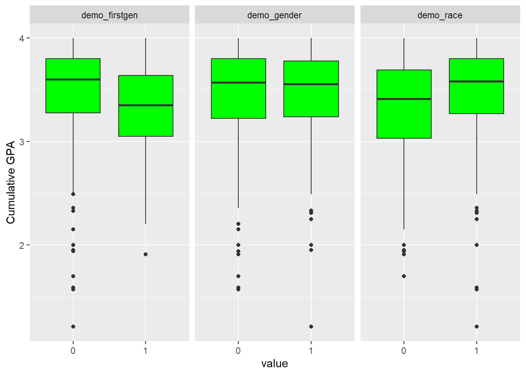

```r
df$demo_race <- factor(df$demo_race)
df$demo_gender <- factor(df$demo_gender)
df$demo_firstgen <- factor(df$demo_firstgen)

df %>% select(.,demo_race,demo_gender,demo_firstgen) %>% gather(.) %>% ggplot(.,mapping=aes(x=value,y=rep(df$cum_gpa,3)))+geom_boxplot(fill="green")+facet_wrap(~key,scales='free_x')+ ylab("Cumulative GPA")
```

```r
df %>% select(.,demo_race) %>% table(.)
```

```
## demo_race
##   0   1
## 118 507
```

```r
df %>% select(.,demo_gender) %>% table(.)
```

```
## demo_gender
##   0   1
## 261 364
```

```r
df %>% select(.,demo_firstgen) %>% table(.)
```

```
## demo_firstgen
##   0   1
## 522 103
```

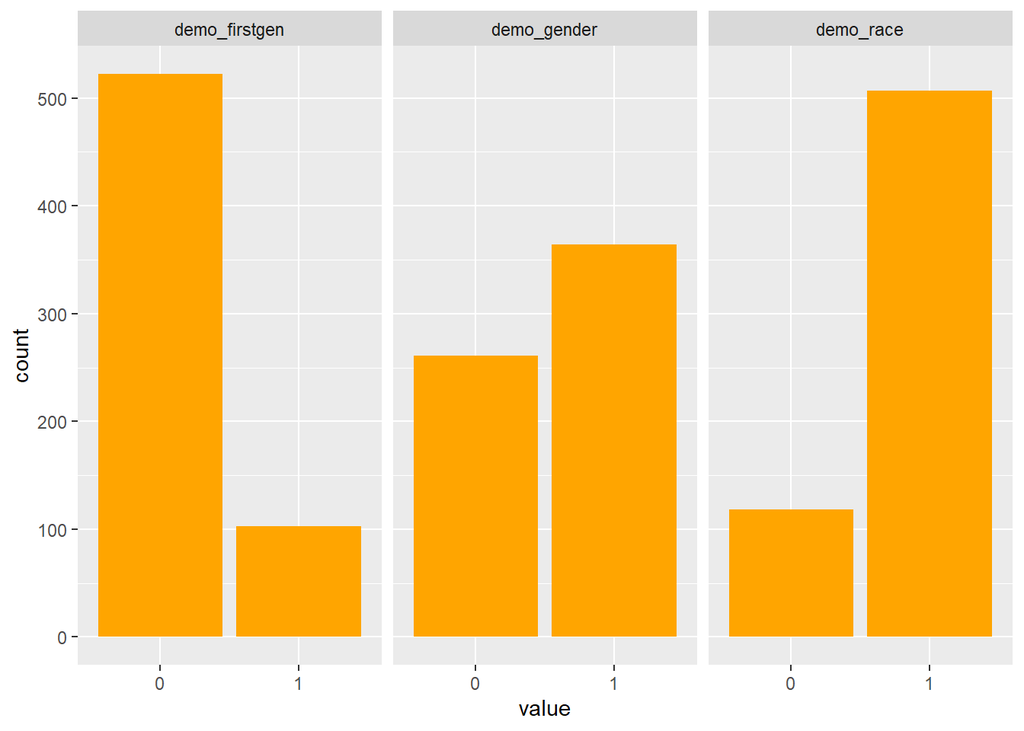

```r
df %>% select(.,demo_race,demo_gender,demo_firstgen) %>% gather(.) %>% ggplot(.,mapping=aes(x=value))+geom_bar(fill="orange")+facet_wrap(~key,scales='free_x')
```

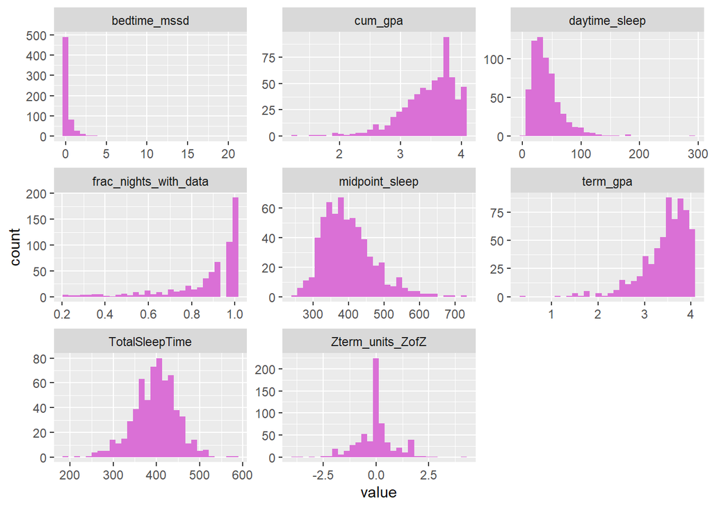

```r
df %>% select(.,-demo_race,-demo_gender,-demo_firstgen) %>% gather(.) %>% ggplot(.,mapping=aes(x=value))+geom_histogram(fill="orchid",bins=30)+facet_wrap(~key,scales='free')
```

Scatter plots of variables with respect to Cumulative GPA. Similar to the histogram plots, the TotalSleepTime and Zterm_units are normally distributed, The other other variable are left or right skewed but the variables have a ceiling effect since the max cumulative GPA is 4. The boxplots are created to detect outliers for the continuous data. Data points outside max and min of the plot (75th percentile + 1.5 * IQR & 25th percnetile - 1.5 * IQR)

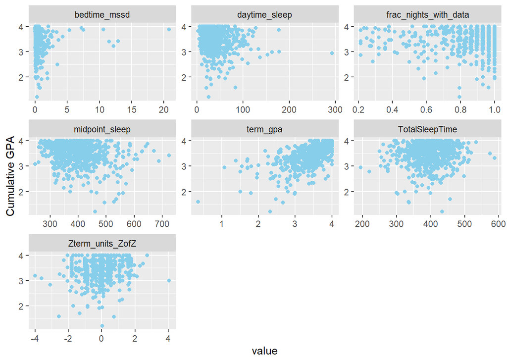

```r
df %>% select(.,-cum_gpa,-demo_race,-demo_gender,-demo_firstgen)%>% gather(.) %>% ggplot(.,mapping=aes(x=value,y=rep(df$cum_gpa,7)))+geom_point(col="skyblue")+facet_wrap(~key,scales='free')+ ylab("Cumulative GPA")
```

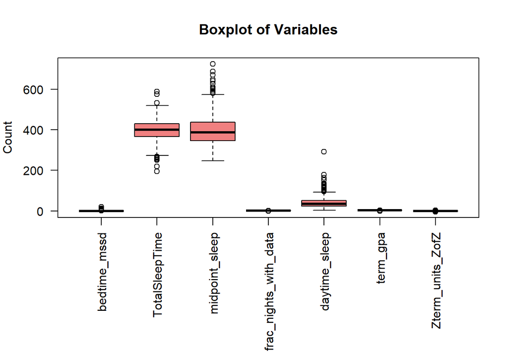

```r
# Create a boxplot for variables
par(mar = c(10,4,4,2)) #boxplot margins
boxplot(df[,c("bedtime_mssd","TotalSleepTime","midpoint_sleep","frac_nights_with_data","daytime_sleep","term_gpa","Zterm_units_ZofZ")],main = "Boxplot of Variables",ylab = "Count",col = "lightcoral",names =c("bedtime_mssd","TotalSleepTime","midpoint_sleep","frac_nights_with_data","daytime_sleep","term_gpa","Zterm_units_ZofZ"),las = 2)  # Rotate x-axis labels to be vertical
```

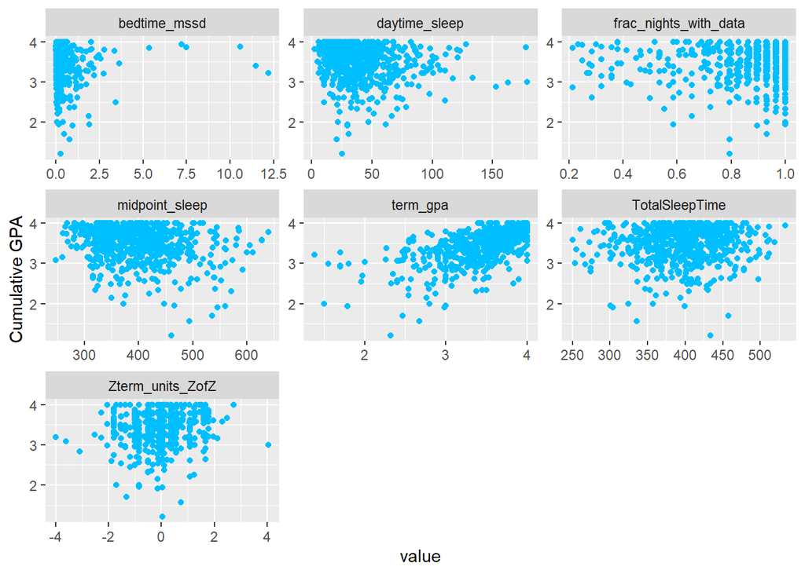

```r
df <- df %>% filter(bedtime_mssd < 15) %>% filter(daytime_sleep<200) %>% filter(term_gpa>1) %>% filter(TotalSleepTime>250 & TotalSleepTime<550) %>% filter(midpoint_sleep<650) #outliers

df %>% select(.,-cum_gpa,-demo_race,-demo_gender,-demo_firstgen)%>% gather(.) %>% ggplot(.,mapping=aes(x=value,y=rep(df$cum_gpa,7)))+geom_point(col="deepskyblue")+facet_wrap(~key,scales='free')+ ylab("Cumulative GPA")
```

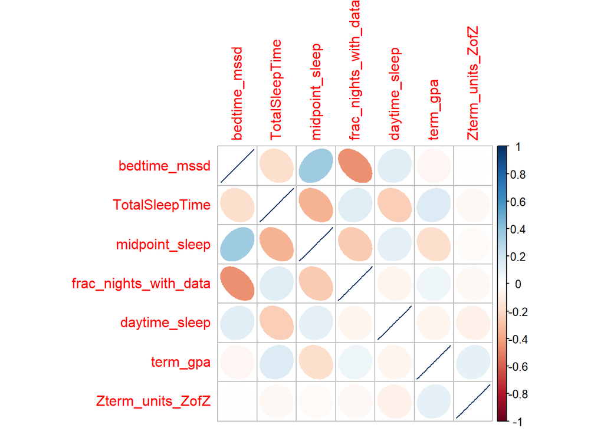

```r
library(corrplot)
df %>% select(.,-demo_race,-demo_gender,-demo_firstgen,-cum_gpa)%>%cor(.)%>%corrplot(.,method="ellipse")
```

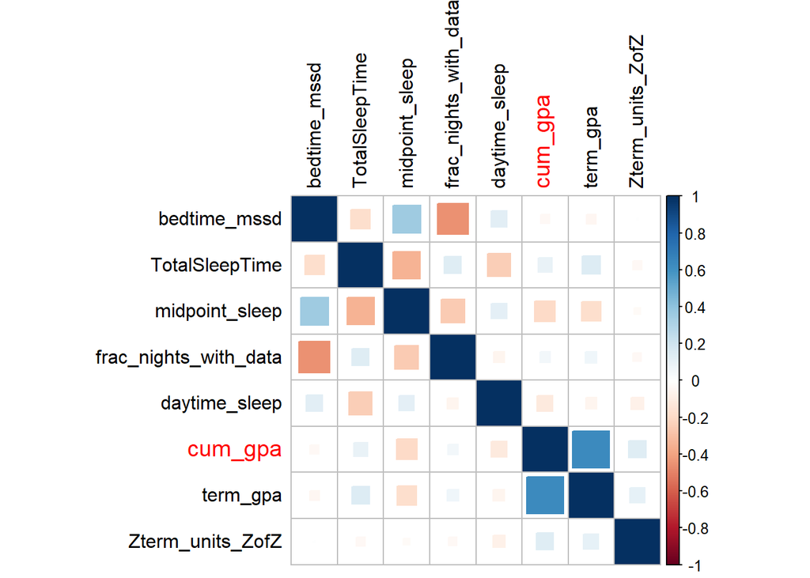

```r
cor_matrix <- df %>% select(-demo_race,-demo_gender,-demo_firstgen) %>% cor()

#Plot the correlation matrix with the target variable ('cum_gpa') highlighted
corrplot(cor_matrix,method = "square",tl.col = ifelse(rownames(cor_matrix) == "cum_gpa","red","black"),tl.cex = ifelse(rownames(cor_matrix) == "cum_gpa",1.2,1))
```